# Tarea4

Leonardo Alvarado

30 de octubre de 2021

## Viusalización de datos (Tarea N° 4)

En est script de R se presentan los resultados de la tarea N° 4 del curso **Fundamentos de Ciencia de Datos** que se llevo a cabo de manera online entre el 27/09/2021 y el 20/10/2021.

Esta asignación corresponde al tema de **Visualización de Datos** y los elementos a incluir son los siguientes:

1. Descargar los 2 conjuntos de datos
2. Hacer agregación de información por municipio/mes
3. Elaborar una visualización que permita encontrar si hay correlación directa/indirecta entre las variables expuestas
4. Crear una visualización que permita a través de filtros de años, ver el top 5 de los municipios con el valor promedio más alto para las variables estudiadas
5. Crear visualización que presente el comportamiento histórico de los datos por municipio de tal manera que se evidencien patrones temporales climáticos
6. De forma paralela, mostrar espacialmente los puntos de los sitios indicando para cada uno de ellos el valor máximo alcanzado

Para el ejercicio se utilizó un conjunto de datos abiertos hidrometereológicos para temperatura y precipitación para el Magdalena descargados del siguiente link. https://invemarsantamarta-my.sharepoint.com/:f:/g/personal/leonardo_arias_invemar_org_co/EnFJInWyylZJlrCFVRy49aoBh17tTv5T1iD3deECHLfP8A?e=O5TF6E

## 1. Descargar los 2 conjuntos de datos

```r
#Carga de datos
prep_df <- read.table("Precip_MAG.csv",sep=',',header=T)
temp_df <- read.table("Temp_MAG.csv",sep=',',header=T)

#Se agrega una columna con la fecha en formato Date
prep_df$Fecha_d <- as.Date(substr(prep_df$FechaObservacion, 0, 10),format = "%m/%d/%Y")
temp_df$Fecha_d <- as.Date(substr(temp_df$FechaObservacion, 0, 10),format = "%m/%d/%Y")
```

## 2. Hacer agregación de información por municipio/mes

```r
## Preparacion de datos para agregación de las variables precipitación y temperatura
#Se agrega una columna con el año y mes de la medición
prep_df$YearMonth <-format(prep_df$Fecha_d,format='%Y-%m')
temp_df$YearMonth <-format(temp_df$Fecha_d,format='%Y-%m')

#Extraemos de cada Dataframe las columnas de interes
df_pre <- prep_df[c('Municipio', 'YearMonth', 'ValorObservado')]
df_tem <- temp_df[c('Municipio', 'YearMonth',  'ValorObservado')]

#Agregamos una columna con el nombre de la variable que se mide
df_pre$Variable <- 'Precipitacion'
df_tem$Variable <- 'Temperatura'

# Se integran los datos en un solo dataframe una debajo del otro
df_tot <- rbind(df_pre,df_tem)

#Redimensionamos eldataframe para tener precipitacion y temperatura en la misma fila
library(reshape2)
datos2 <- dcast(df_tot, Municipio + YearMonth  ~ Variable, value.var="ValorObservado",fun.aggregate = mean)
datos3 <- na.omit(datos2)
```

Se muestran los primeras filas del dataframe

```r
head(datos3)
```

```
##                Municipio YearMonth Precipitacion Temperatura
## 67 ARIGUANÍ (EL DIFICIL)   2017-01    0.47858250    27.78411
## 68 ARIGUANÍ (EL DIFICIL)   2017-02    0.43230967    28.62431
## 69 ARIGUANÍ (EL DIFICIL)   2017-03    0.49206134    28.24330
## 70 ARIGUANÍ (EL DIFICIL)   2017-04    0.56204630    28.64833
## 71 ARIGUANÍ (EL DIFICIL)   2017-05    0.28173300    27.49754
## 72 ARIGUANÍ (EL DIFICIL)   2017-06    0.02756827    27.64851
```

### 3.Elaborar una visualización que permita encontrar si hay correlación directa/indirecta entre las variables expuestas

EN el gráfico se muestra la relación entre las variables precipitación y temperatura y en la mayoría se puede apreciar una relación inversa entre ellas.

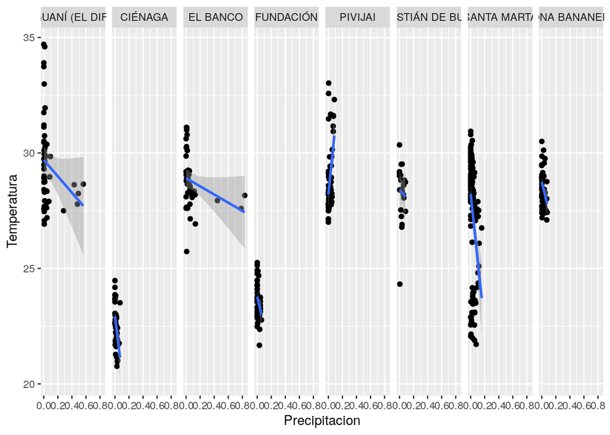

```r
library(ggplot2)
ggplot(datos3, aes(x=Precipitacion, y=Temperatura)) + geom_point() + geom_smooth(method='lm', formula= y~x) + facet_grid(~ Municipio)
```

## 4. Crear una visualización que permita a través de filtros de años, ver el top 5 de los municipios con el valor promedio más alto para las variables estudiadas

En esta sección se gnera los graficos de barras con el top de los 5 municipios con los mayores valores promedios de precipitación y temperatura

```r
datos3$Year <- substr(datos3$YearMonth,1,4)
library(dplyr)
datos4 <- datos3 %>%  group_by(Municipio,Year) %>% summarise(prec_prom = mean(Precipitacion),
                                                   tem_prom = mean(Temperatura))
```

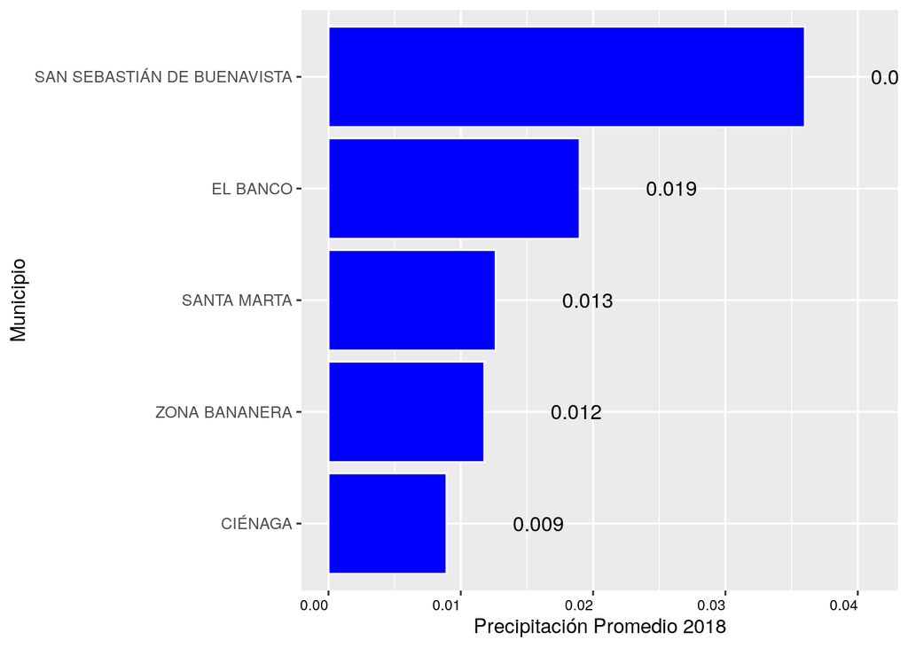

```r
val_year <- 2018
datos5 <- datos4[datos4$Year==val_year,] %>% arrange(desc(prec_prom))
datos6 <- datos4[datos4$Year==val_year,] %>% arrange(desc(tem_prom))

ggplot(datos5[1:5,], aes(reorder(x=Municipio,prec_prom), y=prec_prom)) + geom_bar(stat = "identity",color= 'white',fill="blue") +
  xlab("Municipio")+ylab("Precipitación Promedio 2018") +
  theme(axis.text.x = element_text(angle = 0, hjust = 1,size=8,colour="black")) +
  geom_text(data=datos5[1:5,],aes(x=Municipio,y=prec_prom+0.005,label=round(prec_prom,3)),hjust=0,size=4)+coord_flip()
```

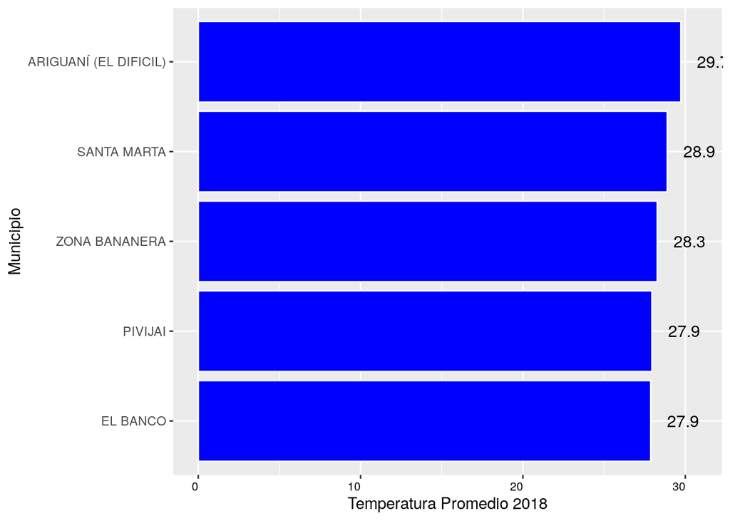

```r
ggsave(filename='TopMunicipios2018_prec.png',width = 12,height = 8,dpi=300)

ggplot(datos6[1:5,], aes(reorder(x=Municipio,tem_prom), y=tem_prom)) + geom_bar(stat = "identity",color= 'white',fill="blue") +
  xlab("Municipio")+ylab("Temperatura Promedio 2018") +
  theme(axis.text.x = element_text(angle = 0, hjust = 1,size=8,colour="black")) +
  geom_text(data=datos6[1:5,],aes(x=Municipio,y=tem_prom+1,label=round(tem_prom,1)),hjust=0,size=4)+coord_flip()
```

```r
ggsave(filename='TopMunicipios2018_tem.png',width = 12,height = 8,dpi=300)
```